# The_Analytics_Edge_edX_MIT15.071x_June2015_3

Course Notes by Nishant Upadhyay Unit4:Trees

30 June 2015

*Source file* ⇒ The_Analytics_Edge_edX_MIT15.071x_June2015_3.rmd

# Unit 4: Trees

## Preliminaries

- These are my notes for the lectures of the [The_Analytics_Edge_edX_MIT15.0 71x_June2015“](https://courses.edx.org/courses/course-v1:MITx+15.071x_2a+2T2015) by Professor Dimitris Bertsimas. The goal of these notes is to provide the reproducible R code for all the lectures.
- A good list of resources about using R for Classification And Regression Trees(CART) are given below:
- [Quick-R_ Tree-Based Models](http://www.statmethods.net/advstats/cart.html)
- [Classification And Regression Trees : A Practical Guide for Describing a Dataset_Leo Pekelis_standford Univ](http://statweb.stanford.edu/~lpekelis/talks/13_datafest_cart_talk.pdf)
- [A Brief Tour of the Trees and Forests _ Statistical Research](http://statistical-research.com/a-brief-tour-of-the-trees-and-forests/?utm_source=rss&utm_medium=rss&utm_campaign=a-brief-tour-of-the-trees-and-forests)
- [Classification and Regression Trees - CMU Statistics](http://www.stat.cmu.edu/~cshalizi/350/lectures/22/lecture-22.pdf)
- [Classification and Regression Trees - Statistics Textbook](http://documents.software.dell.com/Statistics/Textbook/Classification-and-Regression-Trees)
- [Plotting rpart trees with prp()_user manual](http://www.milbo.org/rpart-plot/prp.pdf)
- [Draw nicer Classification and Regression Trees with the rpart.plot package](http://blog.revolutionanalytics.com/2013/06/plotting-classification-and-regression-trees-with-plotrpart.html)
- [Comparing a CART model to Random Forest (Part 1)](http://www.analyticsvidhya.com/blog/2014/06/comparing-cart-random-forest-1/)
- [Introduction to Random forest - Simplified](http://www.analyticsvidhya.com/blog/2014/06/introduction-random-forest-simplified/l)
- [2 main differences between classification and regression trees](http://www.simafore.com/blog/bid/62482/2-main-differences-between-classification-and-regression-trees)
- [Classification and Regression Tree Analysis_Jake Morgan_BostonUniv.](http://www.statmethods.net/advstats/cart.html)
- [k-Fold Cross Validation made simple](http://www.analyticsvidhya.com/blog/2015/05/k-fold-cross-validation-simple/?utm_source=Twitter&utm_medium=Social&utm_campaign=150707)
- [What is good in a decision tree, a large or a small leaf size?](http://discuss.analyticsvidhya.com/t/what-is-good-in-a-decision-tree-a-large-or-a-small-leaf-size/2108)

**A quick primer on Classification And Regression Trees (CART)**

Classification trees, as the name implies are used to separate the dataset into classes belonging to the response variable. Usually the response variable has two classes: Yes or No (1 or 0). If the target variable has more than 2 categories, then a variant of the algorithm, called C4.5, is used. For binary splits however, the standard CART procedure is used. Thus classification trees are used when the response or target variable is categorical in nature.

Regression trees are needed when the response variable is numeric or continuous. For example, the predicted price of a consumer good. Thus regression trees are applicable for prediction type of problems as opposed to classification.

Keep in mind that in either case, the predictors or independent variables may be categorical or numeric. It is the **target variable** that determines the type of decision tree needed.

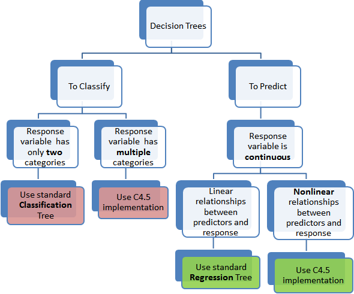

which-type-of-decision-tree-to-use

## Judge Jury & classifier_An introduction to Trees_1

From the course slides:

**ABOUT THE DATA**

Cases from 1994 through 2001.

In this period, the same nine justices presided SCOTUS: + Breyer, Ginsburg, Kennedy, O’Connor, Rehnquist (Chief Justice), Scalia, Souter, Stevens, Thomas + Rare data set - longest period of time with the same set of justices in over 180 years.

We will focus on predicting Justice Stevens’ decisions:

- Started out moderate, but became more liberal
- Self-proclaimmed conservative

**The Variables**

In this problem, our **dependent variable** is whether or not Justice Stevens voted to reverse the lower court decision.  
This is a binary variable, **Reverse**, taking values:

- **1** if Justice Stevens decided to **reverse** or overturn the lower court decision.
- **0** if Justice Stevens voted to **affirm** or maintain the lower court decision.

Our **independent variables** are six different properties of the case.

- **Circuit**: Circuit court of origin, *13 courts* (1st - 11th , DC, FED).
- **Issue**: Issue area of case, *11 areas* (*e.g.*, civil rights, federal taxation).
- **Petitioner**: type of petitioner, *12 categories* (*e.g.*, US, an employer).
- **Respondent**: type of respondent *12 categories* (same as for *Petitioner*).
- **LowerCourt**: Ideological direction of lower court decision (this was based on the judgment by the authors of the study), *2 categories*:
  - **conservative**
  - **liberal**
- **Unconst**: whether petitioner argued that a law/practice was unconstitutional, *binary variable*.

### VIDEO 1: THE SUPREME COURT

QUICK QUESTION

How much data do you think Andrew Martin should use to build his model?

Ans:Information from all cases with the same set of justices as those he is trying to predict. Data from cases where the justices were different might just add noise to our problem.

EXPLANATION:Andrew Martin should use all data from the cases with the same set of justices. The justices do not change every year, and typically you want to use as much data as you have available.

### VIDEO 2: CART

QUICK QUESTION

Suppose that you have the following CART tree:

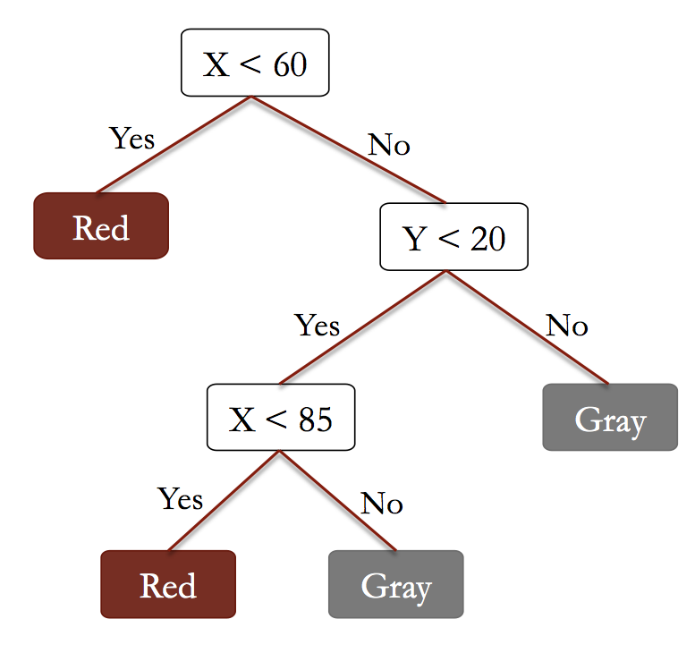

QQ2_SupremeCourt

How many splits are in this tree?

Ans:3

For which data observations should we predict “Red”, according to this tree? Select all that apply.

Ans: If X is less than 60, and Y is any value. & If X is greater than or equal to 60 and less than 85, and Y is less than 20.

EXPLANATION:This tree has three splits. The first split says to predict “Red” if X is less than 60, regardless of the value of Y. Otherwise, we move to the second split. The second split says to check the value of Y - if it is greater than or equal to 20, predict “Gray”. Otherwise, we move to the third split. This split checks the value of X again. If X is less than 85 (and greater than or equal to 60 by the first split) and Y is less than 20, then we predict “Red”. Otherwise, we predict “Gray”.

### VIDEO 3: SPLITTING AND PREDICTIONS

QUICK QUESTION

Suppose you have a subset of 20 observations, where 14 have outcome A and 6 have outcome B. What proportion of observations have outcome A?

```r
14/(14+6)
```

```
## [1] 0.7
```

Ans: 0.7 (The fraction of observations that have outcome A is 14/20 = 0.7.)

QUICK QUESTION

The following questions ask about the subset of 20 observations from the previous question.

If we set the threshold to 0.25 when computing predictions of outcome A, will we predict A or B for these observations?

Ans:A

If we set the threshold to 0.5 when computing predictions of outcome A, will we predict A or B for these observations?

Ans:A

If we set the threshold to 0.75 when computing predictions of outcome A, will we predict A or B for these observations?

Ans:B

EXPLANATION:Since 70% of these observations have outcome A, we will predict A if the threshold is below 0.7, and we will predict B if the threshold is above 0.7.

### VIDEO 4: CART IN R (R script reproduced here)

**Logistic Regression**

We can first try to use logistic regression classification technique.

```r
stevens_full <- read.csv("stevens.csv", stringsAsFactor = TRUE)
str(stevens_full)
```

```
## 'data.frame':    566 obs. of  9 variables:
##  $ Docket    : Factor w/ 566 levels "00-1011","00-1045",..: 63 69 70 145 97 181 242 289 334 436 ...
##  $ Term      : int  1994 1994 1994 1994 1995 1995 1996 1997 1997 1999 ...
##  $ Circuit   : Factor w/ 13 levels "10th","11th",..: 4 11 7 3 9 11 13 11 12 2 ...
##  $ Issue     : Factor w/ 11 levels "Attorneys","CivilRights",..: 5 5 5 5 9 5 5 5 5 3 ...
##  $ Petitioner: Factor w/ 12 levels "AMERICAN.INDIAN",..: 2 2 2 2 2 2 2 2 2 2 ...
##  $ Respondent: Factor w/ 12 levels "AMERICAN.INDIAN",..: 2 2 2 2 2 2 2 2 2 2 ...
##  $ LowerCourt: Factor w/ 2 levels "conser","liberal": 2 2 2 1 1 1 1 1 1 1 ...
##  $ Unconst   : int  0 0 0 0 0 1 0 1 0 0 ...
##  $ Reverse   : int  1 1 1 1 1 0 1 1 1 1 ...
```

```r
#Some of the variables are not interesting for our purpose, namely `Docket` and `Term` and we remove them.
stevens <- stevens_full[, -c(1, 2)]

#logistic model
# model_LogRegr <- glm(Reverse ~ . - Docket - Term, data = stevens, family = binomial)
model_LogRegr <- glm(Reverse ~ ., data = stevens, family = binomial)

summary(model_LogRegr)
```

```
##
## Call:
## glm(formula = Reverse ~ ., family = binomial, data = stevens)
##
## Deviance Residuals:
##     Min       1Q   Median       3Q      Max
## -2.4748  -0.9222   0.4212   0.8805   2.2353
##
## Coefficients:
##                                       Estimate Std. Error z value Pr(>|z|)
## (Intercept)                            0.54410    2.08161   0.261 0.793797
## Circuit11th                            0.99854    0.55292   1.806 0.070926
## Circuit1st                             0.76049    0.72138   1.054 0.291783
## Circuit2nd                             1.42816    0.58598   2.437 0.014801
## Circuit3rd                             0.04341    0.61757   0.070 0.943960
## Circuit4th                             1.48778    0.60068   2.477 0.013255
## Circuit5th                             1.68235    0.56190   2.994 0.002753
## Circuit6th                             1.48956    0.59973   2.484 0.013002
## Circuit7th                             0.49603    0.55787   0.889 0.373925
## Circuit8th                             0.26834    0.55420   0.484 0.628253
## Circuit9th                             1.14267    0.47906   2.385 0.017069
## CircuitDC                              0.61482    0.60133   1.022 0.306578
## CircuitFED                             0.25634    0.64661   0.396 0.691786
## IssueCivilRights                      -0.03997    1.40847  -0.028 0.977360
## IssueCriminalProcedure                -0.15254    1.41269  -0.108 0.914012
## IssueDueProcess                        0.30429    1.43514   0.212 0.832085
## IssueEconomicActivity                  0.13116    1.38507   0.095 0.924557
## IssueFederalismAndInterstateRelations  0.13246    1.44584   0.092 0.927005
## IssueFederalTaxation                  -0.86018    1.54330  -0.557 0.577278
## IssueFirstAmendment                   -0.75179    1.42809  -0.526 0.598592
## IssueJudicialPower                    -0.08953    1.38479  -0.065 0.948449
## IssuePrivacy                           1.54454    1.61703   0.955 0.339492
## IssueUnions                           -0.44031    1.48202  -0.297 0.766390
## PetitionerBUSINESS                     1.28748    1.31922   0.976 0.329094
## PetitionerCITY                         0.21754    1.49548   0.145 0.884343
## PetitionerCRIMINAL.DEFENDENT           2.13822    1.33785   1.598 0.109987
## PetitionerEMPLOYEE                     1.78408    1.37351   1.299 0.193973
## PetitionerEMPLOYER                     0.65596    1.45800   0.450 0.652779
## PetitionerGOVERNMENT.OFFICIAL          1.30488    1.35869   0.960 0.336856
## PetitionerINJURED.PERSON               0.59468    1.51320   0.393 0.694323
```

[output cut: 60 more lines]

```
## RespondentPOLITICIAN                  .
## RespondentSTATE                       .
## RespondentUS                          **
## LowerCourtliberal                     ***
## Unconst
## ---
## Signif. codes:  0 '***' 0.001 '**' 0.01 '*' 0.05 '.' 0.1 ' ' 1
##
## (Dispersion parameter for binomial family taken to be 1)
##
##     Null deviance: 779.86  on 565  degrees of freedom
## Residual deviance: 622.81  on 519  degrees of freedom
## AIC: 716.81
##
## Number of Fisher Scoring iterations: 4
```

We get a model where some of the most significant variables are:

- whether or not the case is from the 2nd circuit court, with a coefficient of **1.428**
- whether or not the case is from the 4th circuit court, with a coefficient of **1.488**
- whether or not the lower court decision was liberal, with a coefficient of **-1.162**

While this tells us that the case being from the 2nd or 4th circuit courts is predictive of Justice Stevens reversing the case, and the lower court decision being liberal is predictive of Justice Stevens affirming the case, it’s *difficult to understand which factors are more important* due to things like the **scales of the variables**, and the **possibility of multicollinearity**.

It’s also difficult to quickly evaluate what the **prediction** would be for a **new case**.

**Classification and Regression Trees (*CART*)**

So instead of logistic regression, Martin and his colleagues used a method called *classification and regression trees*, or **CART**.

This method builds what is called a *tree* by **splitting on the values of the independent variables**.  
To predict the outcome for a new observation or case, you can follow the splits in the tree and at the end, you predict the most frequent outcome in the training set that followed the same path.

Some advantages of *CART* are that:

- it **does not assume a linear model**, like logistic regression or linear regression, and
- it is a **very interpretable** model.

**Example of CART splits**

This plot shows sample data for two independent variables, *x* and *y*, and each data point is colored by the outcome variable, red or gray.  
CART tries to split this data into subsets so that *each subset is as pure or homogeneous as possible*. The first three splits that CART would create are shown here.

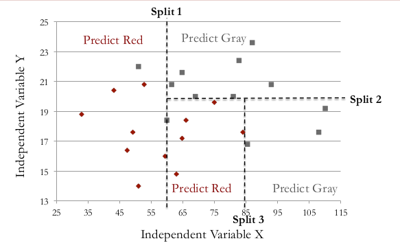

example

Then the standard prediction made by a *CART* model is just a **majority vote** within each subset.

A *CART* model is represented by what we call a **tree**.

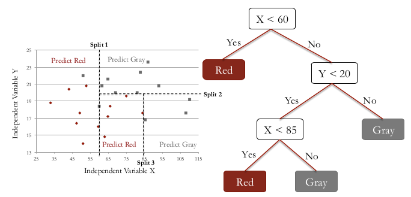

example

The tree for the splits we just generated is shown on the right.

- The first split tests whether the variable $x < 60$.
  - If yes, the model says to predict red, and
  - If no, the model moves on to the next split.
- The second split checks whether or not $y < 20$.
  - If no, the model says to predict gray.
  - If yes, the model moves on to the next split.
- The third split checks whether or not $x < 85$.
  - If yes, then the model says to predict red, and
  - if no, the model says to predict gray.

**CART and splitting**

In the previous example shows a *CART* tree with three splits, but why not two, or four, or even five?

There are different ways to *control how many splits are generated*.

- One way is by **setting a lower bound for the number of data points in each subset**.  
  In **R**, this is called the `minbucket` parameter, for the minimum number of observations in each bucket or subset.  
  The *smaller* `minbucket` is, the more splits will be generated. But if it’s too small, overfitting will occur.  
  This means that *CART* will fit the training set almost perfectly.  
  This is bad because then the model will probably not perform well on test set data or new data.  
  On the other hand, if the `minbucket` parameter is *too large*, the model will be too simple and the accuracy will be poor.

**Predictions from *CART***

In each subset of a *CART* tree, we have a bucket of observations, which may contain both possible outcomes. In the Supreme Court case, we will be classifying observations as either *affirm* or *reverse*, again a binary outcome, as in the example shown above.

In the example we classified each subset as either red or gray depending on the **majority** in that subset.

Instead of just taking the majority outcome to be the prediction, we can **compute the percentage** of data in a subset of each type of outcome. As an example, if we have a subset with 10 affirms and two reverses, then 83% of the data is affirm.  
Then, just like in logistic regression, we can use a **threshold** value **to obtain our prediction**.  
For this example, we would predict affirm with a *threshold of 0.5* since the majority is affirm.

But if we increase that *threshold to 0.9*, we would predict reverse for this example.

Then by varying the threshold value, we can compute an **ROC curve** and compute an **AUC** value **to evaluate our model**.

```r
# Unit 4 - "Judge, Jury, and Classifier" Lecture


# VIDEO 4

# Read in the data
stevens = read.csv("stevens.csv")
str(stevens)
```

```
## 'data.frame':    566 obs. of  9 variables:
##  $ Docket    : Factor w/ 566 levels "00-1011","00-1045",..: 63 69 70 145 97 181 242 289 334 436 ...
##  $ Term      : int  1994 1994 1994 1994 1995 1995 1996 1997 1997 1999 ...
##  $ Circuit   : Factor w/ 13 levels "10th","11th",..: 4 11 7 3 9 11 13 11 12 2 ...
##  $ Issue     : Factor w/ 11 levels "Attorneys","CivilRights",..: 5 5 5 5 9 5 5 5 5 3 ...
##  $ Petitioner: Factor w/ 12 levels "AMERICAN.INDIAN",..: 2 2 2 2 2 2 2 2 2 2 ...
##  $ Respondent: Factor w/ 12 levels "AMERICAN.INDIAN",..: 2 2 2 2 2 2 2 2 2 2 ...
##  $ LowerCourt: Factor w/ 2 levels "conser","liberal": 2 2 2 1 1 1 1 1 1 1 ...
##  $ Unconst   : int  0 0 0 0 0 1 0 1 0 0 ...
##  $ Reverse   : int  1 1 1 1 1 0 1 1 1 1 ...
```

```r
#Some of the variables are not interesting for our purpose, namely `Docket` and `Term` and we remove them.
stevensless <- stevens[, -c(1, 2)]
library(caTools)
set.seed(3000) # to get the same split everytime
spl1 = sample.split(stevensless$Reverse, SplitRatio = 0.7)
Train1 = subset(stevensless, spl1==TRUE)
Test1 = subset(stevensless, spl1==FALSE)

#Fit _Logistic Regression_ model
#As a reference we also fit a _logistic regression_ model to the _training_ data set:
model_LogRegr <- glm(Reverse ~ ., data = Train1, family = binomial)
summary(model_LogRegr)
```

```
##
## Call:
## glm(formula = Reverse ~ ., family = binomial, data = Train1)
##
## Deviance Residuals:
##     Min       1Q   Median       3Q      Max
## -2.3832  -0.9186   0.3458   0.8470   2.2290
##
## Coefficients:
##                                       Estimate Std. Error z value Pr(>|z|)
## (Intercept)                            0.45008    2.34027   0.192  0.84749
## Circuit11th                            1.11621    0.65391   1.707  0.08783
## Circuit1st                             0.45867    1.16360   0.394  0.69344
## Circuit2nd                             2.31471    0.72699   3.184  0.00145
## Circuit3rd                             0.46020    0.74762   0.616  0.53819
## Circuit4th                             1.95459    0.72631   2.691  0.00712
## Circuit5th                             2.03668    0.67009   3.039  0.00237
## Circuit6th                             1.48370    0.71501   2.075  0.03798
## Circuit7th                             0.69997    0.68327   1.024  0.30563
## Circuit8th                             0.78445    0.67347   1.165  0.24411
## Circuit9th                             1.34112    0.58353   2.298  0.02154
## CircuitDC                              0.57449    0.72694   0.790  0.42936
## CircuitFED                             0.63139    0.74354   0.849  0.39579
## IssueCivilRights                       0.15302    1.41314   0.108  0.91377
## IssueCriminalProcedure                -0.08072    1.42975  -0.056  0.95498
## IssueDueProcess                        0.48455    1.44254   0.336  0.73694
## IssueEconomicActivity                  0.21192    1.39093   0.152  0.87891
## IssueFederalismAndInterstateRelations  0.28026    1.48114   0.189  0.84992
## IssueFederalTaxation                  -1.76887    1.71259  -1.033  0.30167
## IssueFirstAmendment                   -0.50309    1.45309  -0.346  0.72918
## IssueJudicialPower                    -0.11009    1.37988  -0.080  0.93641
## IssuePrivacy                           2.39866    1.79602   1.336  0.18170
## IssueUnions                           -0.78603    1.52914  -0.514  0.60723
## PetitionerBUSINESS                     1.36136    1.60051   0.851  0.39500
## PetitionerCITY                        -0.19086    1.79841  -0.106  0.91548
## PetitionerCRIMINAL.DEFENDENT           2.01263    1.61931   1.243  0.21391
## PetitionerEMPLOYEE                     2.09290    1.67320   1.251  0.21099
## PetitionerEMPLOYER                     0.68498    1.75856   0.390  0.69690
## PetitionerGOVERNMENT.OFFICIAL          0.35138    1.62596   0.216  0.82890
## PetitionerINJURED.PERSON               1.46768    1.84218   0.797  0.42562
```

[output cut: 60 more lines]

```
## RespondentPOLITICIAN
## RespondentSTATE
## RespondentUS                          **
## LowerCourtliberal                     **
## Unconst
## ---
## Signif. codes:  0 '***' 0.001 '**' 0.01 '*' 0.05 '.' 0.1 ' ' 1
##
## (Dispersion parameter for binomial family taken to be 1)
##
##     Null deviance: 545.70  on 395  degrees of freedom
## Residual deviance: 428.71  on 349  degrees of freedom
## AIC: 522.71
##
## Number of Fisher Scoring iterations: 5
```

```r
#Out-of-Sample predictions of the _Logistic Regression_ model
predict_LogRegr_Test<- predict(model_LogRegr,type = "response", newdata = Test1)
cmat_LR <- table(Test1$Reverse, predict_LogRegr_Test > 0.5)
cmat_LR
```

```
##
##     FALSE TRUE
##   0    47   30
##   1    27   66
```

```r
accu_LR <- (cmat_LR[1,1] + cmat_LR[2,2])/sum(cmat_LR)
accu_LR
```

```
## [1] 0.6647059
```

```r
#Overall Accuracy = 0.6647
#Sensitivity = 66 / 93 = 0.7097 ( = TP rate)
#Specificity = 47 / 77 = 0.6104
#FP rate = 30 / 77 = 0.3896

###################################################

# Read in the data again for CART modeling
stevens = read.csv("stevens.csv")
str(stevens)
```

```
## 'data.frame':    566 obs. of  9 variables:
##  $ Docket    : Factor w/ 566 levels "00-1011","00-1045",..: 63 69 70 145 97 181 242 289 334 436 ...
##  $ Term      : int  1994 1994 1994 1994 1995 1995 1996 1997 1997 1999 ...
##  $ Circuit   : Factor w/ 13 levels "10th","11th",..: 4 11 7 3 9 11 13 11 12 2 ...
##  $ Issue     : Factor w/ 11 levels "Attorneys","CivilRights",..: 5 5 5 5 9 5 5 5 5 3 ...
##  $ Petitioner: Factor w/ 12 levels "AMERICAN.INDIAN",..: 2 2 2 2 2 2 2 2 2 2 ...
##  $ Respondent: Factor w/ 12 levels "AMERICAN.INDIAN",..: 2 2 2 2 2 2 2 2 2 2 ...
##  $ LowerCourt: Factor w/ 2 levels "conser","liberal": 2 2 2 1 1 1 1 1 1 1 ...
##  $ Unconst   : int  0 0 0 0 0 1 0 1 0 0 ...
##  $ Reverse   : int  1 1 1 1 1 0 1 1 1 1 ...
```

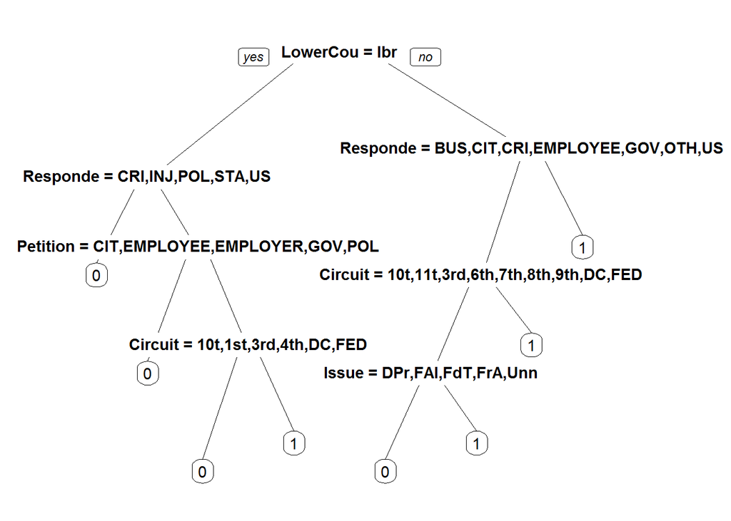

```r
# Split the data
library(caTools)
set.seed(3000) # to get the same split everytime
spl = sample.split(stevens$Reverse, SplitRatio = 0.7)
Train = subset(stevens, spl==TRUE)
Test = subset(stevens, spl==FALSE)

# Install rpart library
#install.packages("rpart")
library(rpart)
#install.packages("rpart.plot")
library(rpart.plot)

# CART model
StevensTree = rpart(Reverse ~ Circuit + Issue + Petitioner + Respondent + LowerCourt + Unconst, data = Train, method="class", minbucket=25)
#method="class" arg tells us to make classification tree and not regression tree.
#minbucket = 25 limits the tree so that it does not overfit to our training set.We selected a value of 25, but we could pick a smaller or larger value.We will see another way to limit the tree later in this lecture.

#The model can be be represented as a decision tree:
prp(StevensTree) #plotting the classification tree
```

```r
# Make predictions
PredictCART = predict(StevensTree, newdata = Test, type = "class") #We need to give type = "class" if we want the majority class predictions.This is like using a threshold of 0.5.

#Now lets assess the accuracy of the model through confusion matrix
cmat_CART<-table(Test$Reverse, PredictCART)  #first arg is the true outcomes and the second is the predicted outcomes
cmat_CART
```

```
##    PredictCART
##      0  1
##   0 41 36
##   1 22 71
```

```r
#lets now compute the overall accuracy

accu_CART <- (cmat_CART[1,1] + cmat_CART[2,2])/sum(cmat_CART)
accu_CART  #(41+71)/(41+36+22+71)
```

```
## [1] 0.6588235
```

```r
#Our baseline model accuracy is the most frequent outcome i.e. the reversal  denoted by code 1
(22+71)/(41+36+22+71)
```

```
## [1] 0.5470588
```

```r
#Sensitivity = 71 / 93 = 0.7634 ( = TP rate)
#Specificity = 41 / 77 = 0.5325
#FP rate = 36 / 77 = 0.4675

#If we had used logistic regression model, we would have got overall accuracy of 0.6647.A baseline model that always predicts Reverse (the most common outcome) has an accuracy of 54.7%.Here the CART model significantly beats the baseline model and is competitive with logistic model as well as MORE INTERPRETABLE than the logistic model.A CART tree is a series of decision rules which can easily be explained.

#Lets evaluate our model using the ROC curve
library(ROCR)
PredictROC = predict(StevensTree, newdata = Test)
head(PredictROC)
```

```
##            0         1
## 1  0.3035714 0.6964286
## 3  0.3035714 0.6964286
## 4  0.4000000 0.6000000
## 6  0.4000000 0.6000000
## 8  0.4000000 0.6000000
## 21 0.3035714 0.6964286
```

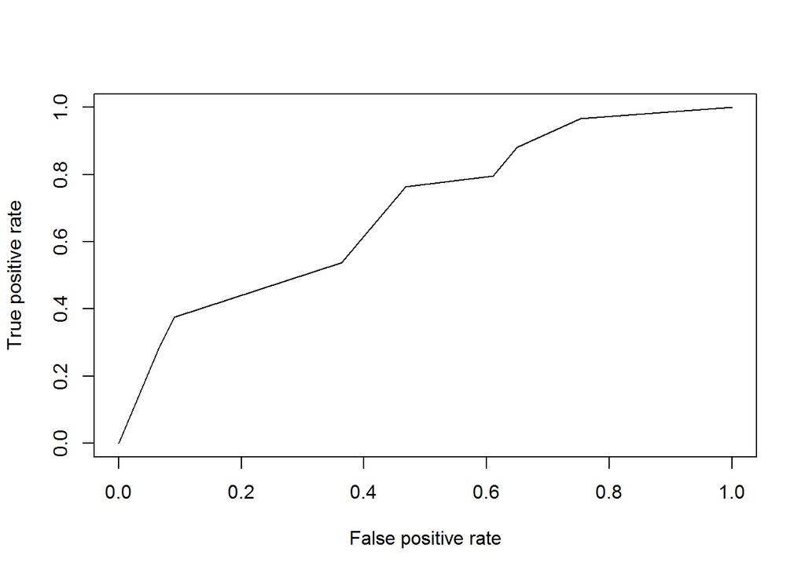

```r
#For each observation in the test set, it gives two numbers which can be thought of as the probability of outcome 0 and the probability of outcome 1.
#More concretely, each test set observation is classified into a subset, or bucket, of our CART tree. These numbers give the percentage of training set data in that subset with outcome 0 and the percentage of data in the training set in that subset with outcome 1.
#We will use the second column as our probabilities to generate an ROC curve.

#First we use the prediction() function with first argument the second column of PredictROC, and second argument the true outcome values, Test$Reverse.
#We pass the output of prediction() to performance() to which we give also two arguments for what we want on the X and Y axes of our ROC curve, true positive rate and false positive rate.
pred = prediction(PredictROC[,2], Test$Reverse)
perf = performance(pred, "tpr", "fpr")

#and the plot
plot(perf)
```

```r
#QUICK QUESTION

#Compute the AUC of the CART model from the previous video, using the following command in your R console:
as.numeric(performance(pred, "auc")@y.values)
```

```
## [1] 0.6927105
```

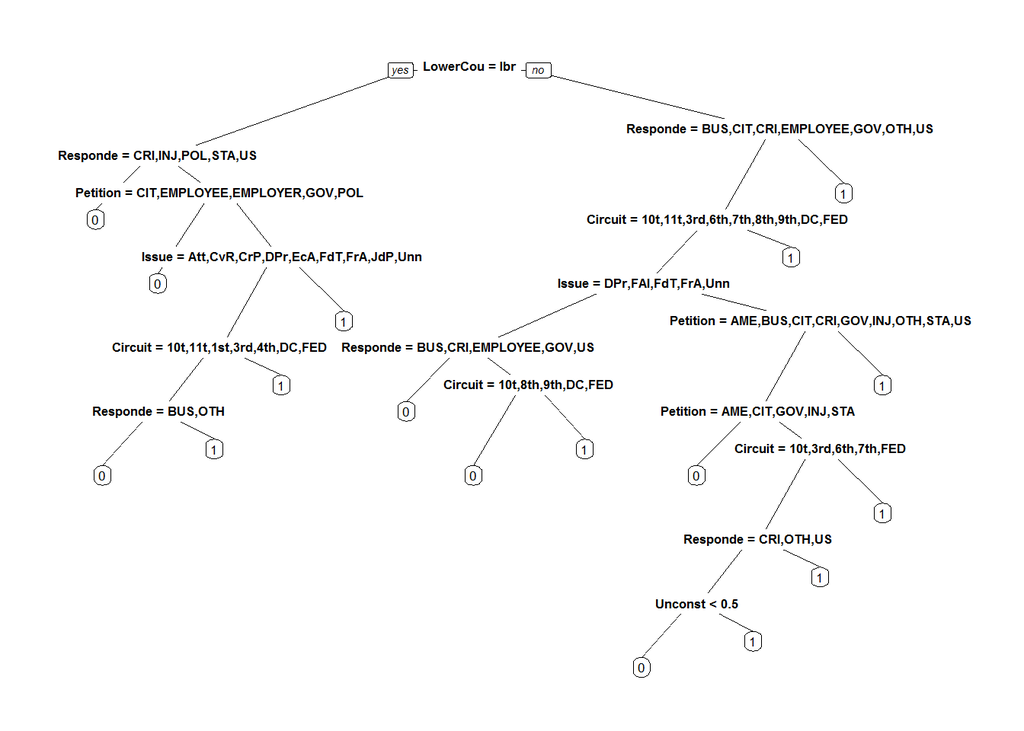

```r
#What is the AUC?
#Ans:0.6927105

#Now, recall that in Video 4, our tree had 7 splits. Let's see how this changes if we change the value of minbucket.

#First build a CART model that is similar to the one we built in Video 4, except change the minbucket parameter to 5. Plot the tree.
# CART model
StevensTree = rpart(Reverse ~ Circuit + Issue + Petitioner + Respondent + LowerCourt + Unconst, data = Train, method="class", minbucket=5) #method="class" arg tells us to make classification tree and not regression tree.
prp(StevensTree) #plotting the classification tree
```

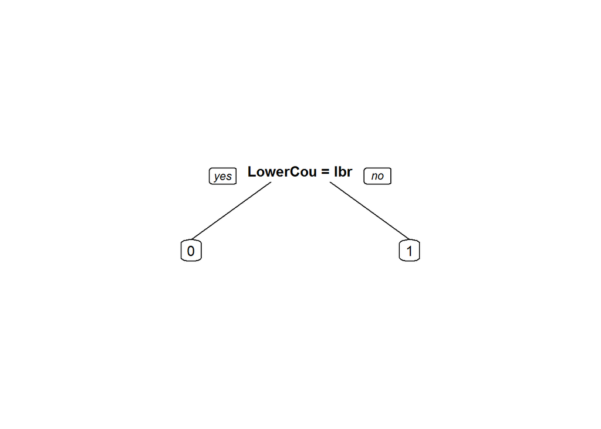

```r
#How many splits does the tree have?
#Ans:16
#EXPLANATION:If you plot the tree with prp(StevensTree), you can see that the tree has 16 splits! This tree is probably overfit to the training data, and is not as interpretable.

#Now build a CART model that is similar to the one we built in Video 4, except change the minbucket parameter to 100. Plot the tree.
StevensTree = rpart(Reverse ~ Circuit + Issue + Petitioner + Respondent + LowerCourt + Unconst, data = Train, method="class", minbucket=100) #method="class" arg tells us to make classification tree and not regression tree.
prp(StevensTree) #plotting the classification tree
```

```r
#How many splits does the tree have?
#Ans:1
#EXPLANATION:If you plot the tree with prp(StevensTree), you can see that the tree only has one split! This tree is probably not fit well enough to the training data.
```